# R para ciencia de datos - Ejercicios 2

Noelí D’Alessio

4/25/2020

```r
library(tidyverse)
library(datos)
```

## 5.5 Añadir nuevas variables con mutate()

5.5.1 no hay ejercicios

5.5.2 Ejercicios

1. Las variables horario_salida y salida_programada tienen un formato conveniente para leer, pero es difícil realizar cualquier cálculo con ellas porque no son realmente números continuos. Transfórmalas hacia un formato más conveniente como número de minutos desde la medianoche.

```r
horas_a_minutos <- function (x){
  (x %/% 100 * 60 + x %% 100) %% 1440
}

horarios_vuelos <- mutate(vuelos,
                              salida_programada_minutos = horas_a_minutos(salida_programada),
                              horario_salida_minutos = horas_a_minutos(horario_salida))

select(horarios_vuelos, salida_programada, salida_programada_minutos, horario_salida, horario_salida_minutos)
```

```
## # A tibble: 336,776 x 4
##    salida_programada salida_programada_minu~ horario_salida horario_salida_minu~
##                <int>                   <dbl>          <int>                <dbl>
##  1               515                     315            517                  317
##  2               529                     329            533                  333
##  3               540                     340            542                  342
##  4               545                     345            544                  344
##  5               600                     360            554                  354
##  6               558                     358            554                  354
##  7               600                     360            555                  355
##  8               600                     360            557                  357
##  9               600                     360            557                  357
## 10               600                     360            558                  358
## # ... with 336,766 more rows
```

2.Compara tiempo_vuelo con horario_llegada - horario_salida. ¿Qué esperas ver? ¿Qué ves?

Esperaría que si resto al horario de llegada el horarios de salida, me daría una cantidad en minutos que sería la misma que el tiempo de vuelo:

```r
vuelos_tiempo <-
  mutate(vuelos,
    horario_llegada = (horario_llegada %/% 100 * 60 + horario_llegada %% 100)%% 1440,
    horario_salida = (horario_salida %/% 100 * 60 + horario_salida %% 100) %% 1440,
    diferencia_tiempo_aire = horario_llegada - horario_salida
                               )

select(vuelos_tiempo, horario_llegada, horario_salida, diferencia_tiempo_aire, tiempo_vuelo)
```

```
## # A tibble: 336,776 x 4
##    horario_llegada horario_salida diferencia_tiempo_aire tiempo_vuelo
##              <dbl>          <dbl>                  <dbl>        <dbl>
##  1             510            317                    193          227
##  2             530            333                    197          227
##  3             563            342                    221          160
##  4             604            344                    260          183
##  5             492            354                    138          116
##  6             460            354                    106          150
##  7             553            355                    198          158
##  8             429            357                     72           53
##  9             518            357                    161          140
## 10             473            358                    115          138
## # ... with 336,766 more rows
```

-Hay varios motivos por los cuales hay muchos vuelos donde la diferencia entre el tiempo de vuelo y el tiempo de vuelo calculado como horario_llegada-horario_salida no coincide: 1. Diferencias en los husos horarios. Estas diferencias deberían dar una hora, dos más de diferencia (divisible por 60). 2.Si llega al día siguiente. Por ejemplo, salió a las 23hs (1380 minutos) y llegó a la 1 (60 minutos), el tiempo de vuelo es de 120 minutos, pero 1380-60 no daría eso. 3.En la documentación, señalan que el tiempo_vuelo es considerado desde el momento en que las ruedas del avión dejan de tocar el piso y cuando al aterrizar las tocan del piso. No se considera el tiempo previo y posterior a esto. Por lo cual, beríamos considerar, en realidad que: tiempo_vuelo <= horario_llegada - horario_salida

Deberíamos pasar las fechas a otro formato como el UTC.

3. Compara horario_salida, salida_programada, y atraso_salida. ¿Cómo esperarías que esos tres números estén relacionados?

Nuevamente, esperaría que atraso_salida - horario_salida + salida_programada sea igual a 0.

```r
retrasos_comparacion<- mutate(vuelos,
                     atraso_salida = horas_a_minutos(atraso_salida),
                     salida_programada = horas_a_minutos(salida_programada),
                     horario_salida = horas_a_minutos(horario_salida),
                     diferencia_retraso = atraso_salida - horario_salida + salida_programada)

select(retrasos_comparacion, salida_programada, horario_salida, atraso_salida, diferencia_retraso)
```

```
## # A tibble: 336,776 x 4
##    salida_programada horario_salida atraso_salida diferencia_retraso
##                <dbl>          <dbl>         <dbl>              <dbl>
##  1               315            317             2                  0
##  2               329            333             4                  0
##  3               340            342             2                  0
##  4               345            344            39                 40
##  5               360            354            34                 40
##  6               358            354            36                 40
##  7               360            355            35                 40
##  8               360            357            37                 40
##  9               360            357            37                 40
## 10               360            358            38                 40
## # ... with 336,766 more rows
```

```r
nrow(filter(retrasos_comparacion, diferencia_retraso != 0))
```

```
## [1] 197604
```

Hay 197604 vuelos donde el atraso y la diferencia entre horario_salida y horario_programado no coinciden. Esto podría deberse a que se retraso un vuelo para el día siguiente.

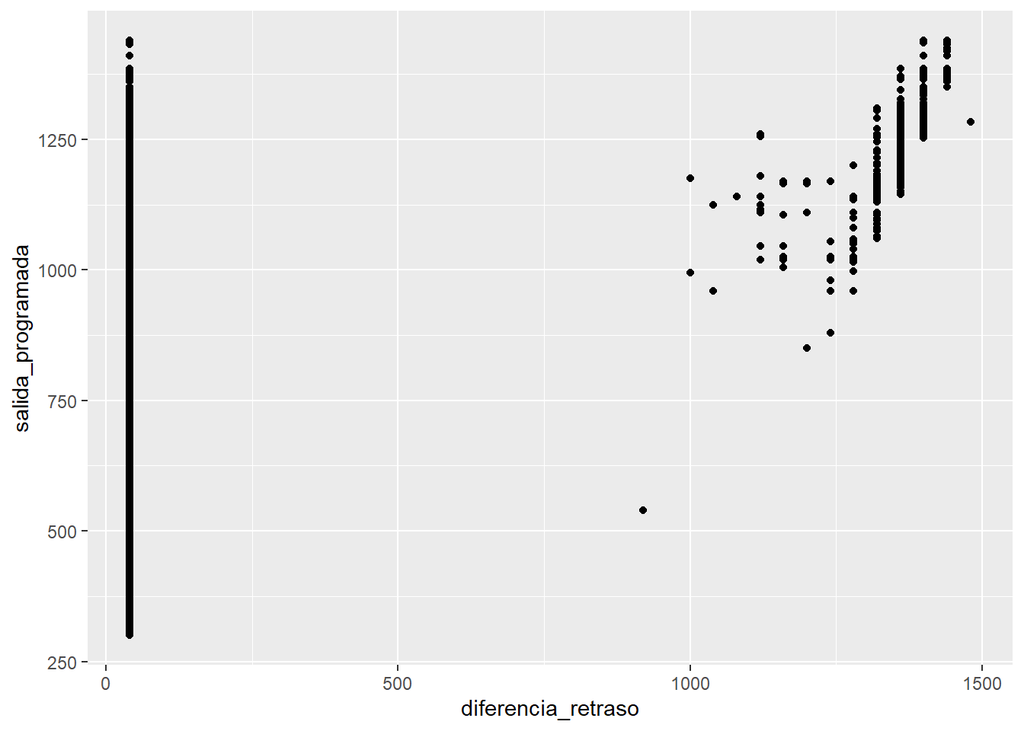

[output not shown]

```r
ggplot(
      filter(retrasos_comparacion, diferencia_retraso > 0),
      aes(y = salida_programada, x = diferencia_retraso)
) +
  geom_point()
```

4.Encuentra los 10 vuelos más retrasados utilizando una función de ordenamiento. ¿Cómo quieres manejar los empates? Lee atentamente la documentación de min_rank(). 5.¿Qué devuelve 1:3 + 1:10? ¿Por qué? 6.¿Qué funciones trigonométricas proporciona R?